# hw03

Farnaz Sahragard

```r
library(gapminder)
library(rmarkdown)
library(tibble)
library(DT)
library(tidyverse)
library(tsibble)
library(scales)
```

```r
library(dplyr)
library(ggplot2)
```

# **Task option 2**: Get The maximum and minimum of GDP per capita for all continents.

## The table and plot below show the maximum and minimum of gdpPercap for all continents.

```r
gapminder %>%
group_by(continent) %>%
summarize(maxgdp = max(gdpPercap),mingdp= min(gdpPercap))
```

```
## # A tibble: 5 x 3
##   continent  maxgdp mingdp
##   <fct>       <dbl>  <dbl>
## 1 Africa     21951.   241.
## 2 Americas   42952.  1202.
## 3 Asia      113523.   331
## 4 Europe     49357.   974.
## 5 Oceania    34435. 10040.
```

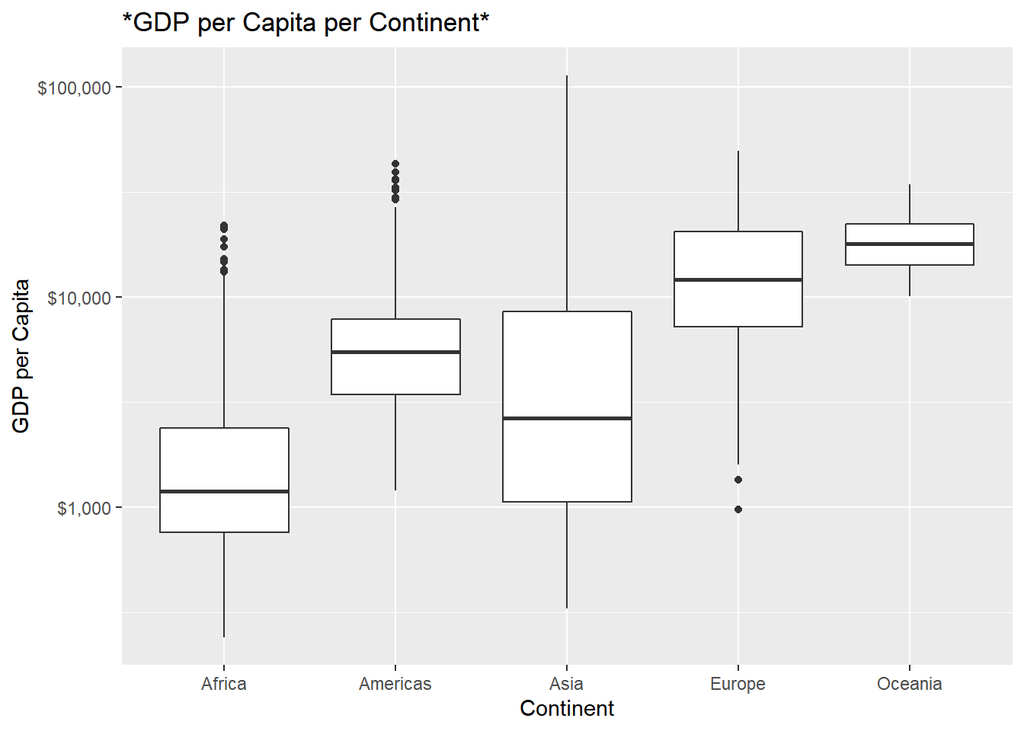

```r
gapminder %>%
  ggplot(aes(continent, gdpPercap)) +
  geom_boxplot(size = 0.5) +
  scale_y_log10(labels = scales::dollar_format()) +
  labs(title = "*GDP per Capita per Continent*", x = "Continent", y = "GDP per Capita")
```

# **Task option 3**: Look at the spread of GDP per capita within the continents.

## The table and plot below show the spread (range, quartiles(Q1,Q2,Q3), interquartile range (IQR), variance (VAR), standard deviation (SD)) of gdpPercap for all continents.

```r
gapminder %>%
  group_by(continent) %>%
  summarize(Range = paste(min(gdpPercap), max(gdpPercap), sep = "~"),
                     Q1 = quantile(gdpPercap, 0.25),
                     Q2 = quantile(gdpPercap, 0.5),
                     Q3 = quantile(gdpPercap, 0.75),
                     IQR = IQR(gdpPercap),
                     VAR = var(gdpPercap),
                     SD = sd(gdpPercap)) %>%
  rename(Continent = continent)
```

```
## # A tibble: 5 x 8
##   Continent Range                   Q1     Q2     Q3    IQR      VAR     SD
##   <fct>     <chr>                <dbl>  <dbl>  <dbl>  <dbl>    <dbl>  <dbl>
## 1 Africa    241.1658765~21951.~   761.  1192.  2377.  1616.   8.00e6  2828.
## 2 Americas  1201.637154~42951.~  3428.  5466.  7830.  4402.   4.09e7  6397.
## 3 Asia      331~113523.1329      1057.  2647.  8549.  7492.   1.97e8 14045.
## 4 Europe    973.5331948~49357.~  7213. 12082. 20461. 13248.   8.75e7  9355.
## 5 Oceania   10039.59564~34435.~ 14142. 17983. 22214.  8072.   4.04e7  6359.
```

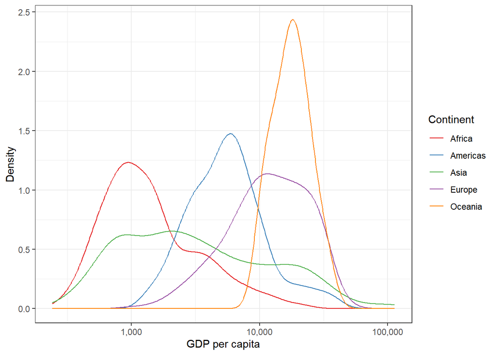

```r
gapminder %>%
  ggplot(aes(gdpPercap, color = continent)) +
  geom_line(stat = "density", size = 0.5) +
  scale_x_log10("GDP per capita", labels = scales::comma_format())+
  scale_y_continuous("Density")+
  theme_bw()+
  scale_color_brewer(palette="Set1", name = "Continent")
```

# **Task option 5**: How is life expectancy changing over time on different continents?

## The table below shows that the minimum, mean, and maximum values of life expectancy has changed over time. The plot shows how the mean of life expectancy changes over time. We can see that the growth speed was not the same for different countries in different times. Life expectancy has increased for most countries over time, but for Africa a drop in life expectancy is seen beetween 1990-2000.

```r
gapminder %>%
  group_by(continent,year) %>%
  summarize(Min = min(lifeExp),
            Mean = mean(lifeExp),
            Max = max(lifeExp)) %>%
  rename(Continent = continent, Year = year)
```

```
## # A tibble: 60 x 5
## # Groups:   Continent [5]
##    Continent  Year   Min  Mean   Max
##    <fct>     <int> <dbl> <dbl> <dbl>
##  1 Africa     1952  30    39.1  52.7
##  2 Africa     1957  31.6  41.3  58.1
##  3 Africa     1962  32.8  43.3  60.2
##  4 Africa     1967  34.1  45.3  61.6
##  5 Africa     1972  35.4  47.5  64.3
##  6 Africa     1977  36.8  49.6  67.1
##  7 Africa     1982  38.4  51.6  69.9
##  8 Africa     1987  39.9  53.3  71.9
##  9 Africa     1992  23.6  53.6  73.6
## 10 Africa     1997  36.1  53.6  74.8
## # ... with 50 more rows
```

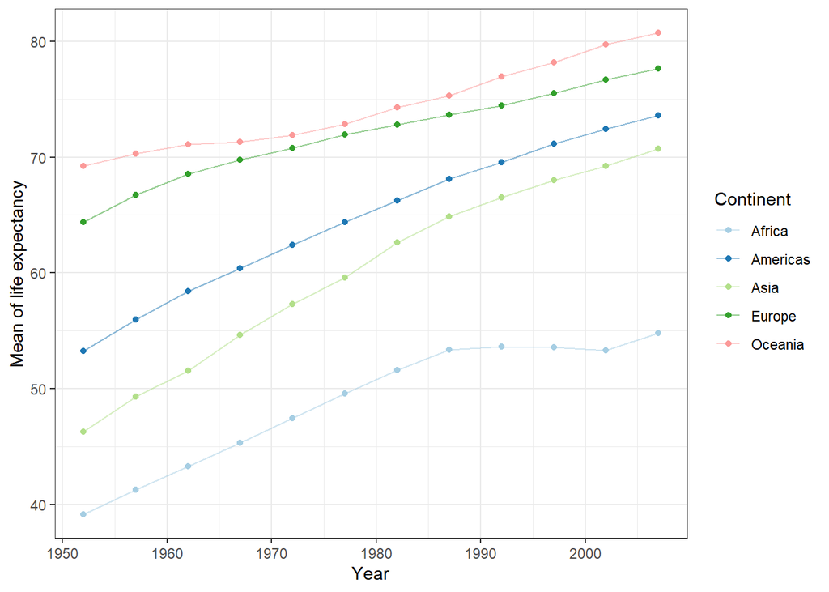

```r
gapminder %>%
  group_by(continent, year) %>%
  summarize(min = min(lifeExp),
            mean = mean(lifeExp),
            max = max(lifeExp)) %>%
  ggplot(aes(year, mean, colour = continent)) +
  geom_line(alpha = 0.5)+
  geom_point()+
  scale_x_continuous("Year")+
  scale_y_continuous("Mean of life expectancy")+
  theme_bw()+
  scale_color_brewer(palette="Paired", name = "Continent")
```